# projet Series chronologiques

## 1.3 plotting des variables de l’étude :

### pour les données de la première phase

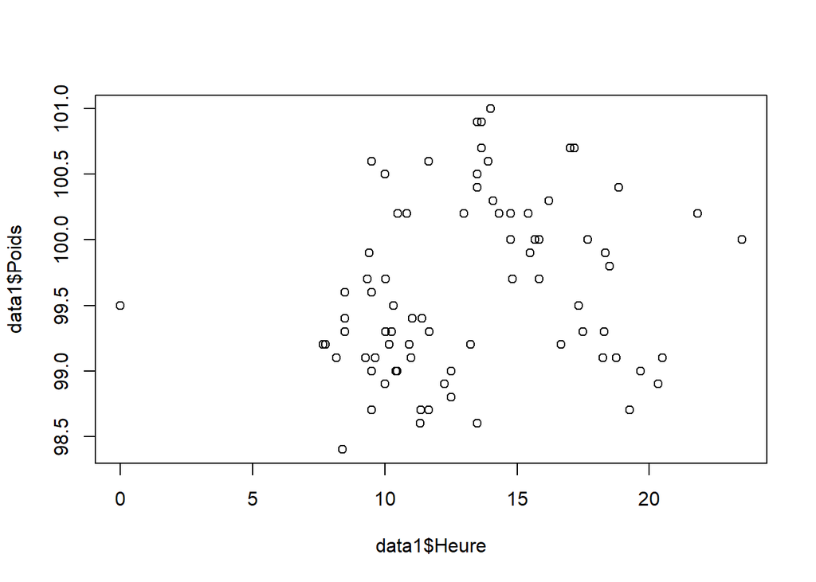

```r
plot(x=data1$Heure, y=data1$Poids)
```

cette donnée à 0h doit etre mis en fin de journée comme 0h = 24h

```r
p <- which(data1$Heure == 0)
```

```r
data1$Heure[p] = 24
```

### pour les données de la deuxième phase

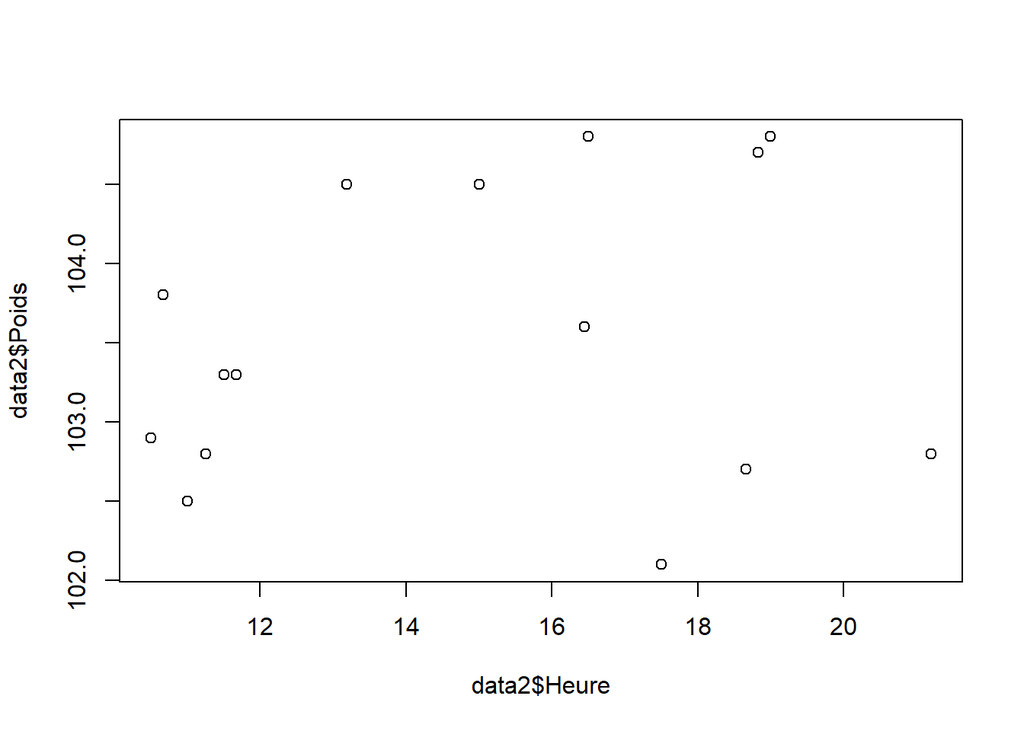

```r
plot(x=data2$Heure, y=data2$Poids)
```

# 2. Lissage par la méthode de regression locale : le poids en fonction de la variable heure

## 2.1 modélisation des différences de poids sans tenir compte du jour, cela donne la variable de poids

```r
res_loess <- loess(Poids~Heure,data=data1,span = 0.3)
```

```r
## ajoutons une colonne des valeurs ajustées dans le data1frame
data1$y <- res_loess$fitted
```

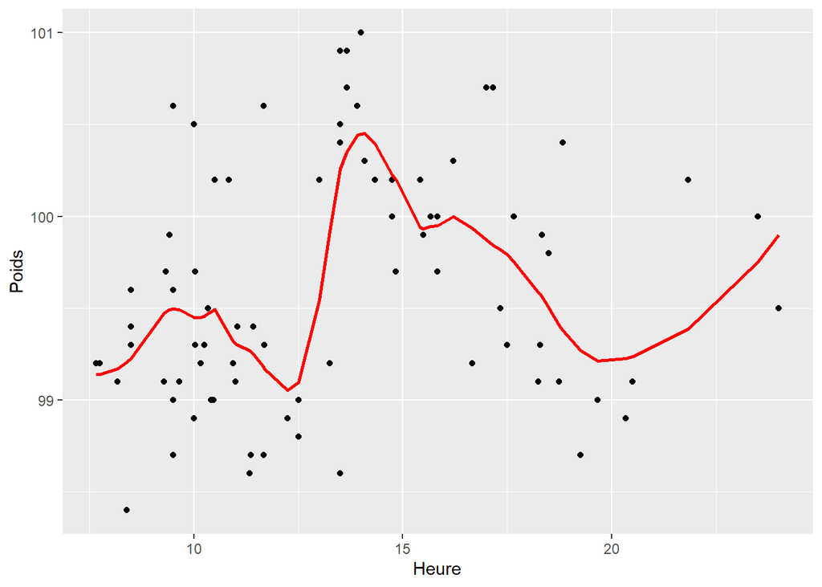

```r
## representation graphique
library(ggplot2)
ggplot(data1,aes(x=Heure,y=Poids)) +
geom_point() +
geom_line(aes(y=y),col="red",size=1)
```

# 3.Calculez l’évolution du poids pendant la seconde phase indépendamment des variations dans la journée.

comme dans la consigne, 104.7kg effectuée à 18h50 on va chercher la valeur lissée à 18h50 donc y dans data1 quand heure = 18h50 et la valeur à midi de la série lissée puis trouver l’ecart entre les deux. puisqu’on a observé 104.7kg à 18h50, on peut en déduire que le poids à midi sur cette journée sera 104.7 kg +- cet ecart.

```r
valeur_lisse_midi <- predict(res_loess, 12.00)
valeur_lisse_midi
```

```
## [1] 99.09176
```

utiliser la fonction predict (loess, newdata) avec newdata = colonne des heures pour lesquelles on veut les predictions

```r
# on calcule les predictions du poids a midi des jours de la 2e phase
data2$poids_lisse <- predict(res_loess, data2$Heure)
```

```r
# on calcule lecart entre la valeur lisse a midi et ces poids a midi
data2$ecart <- valeur_lisse_midi - data2$poids_lisse
```

```r
data2$poids_midi <- data2$Poids + data2$ecart
```

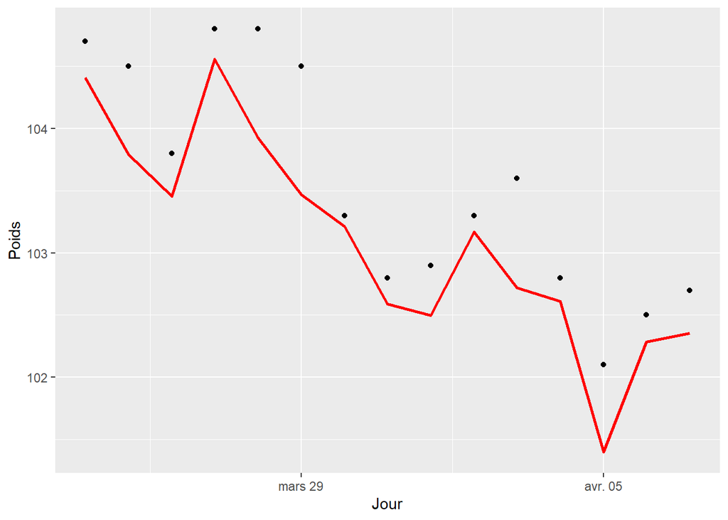

```r
## representation graphique
library(ggplot2)
ggplot(data2,aes(x=Jour,y=Poids)) +
geom_point() +
geom_line(aes(y=poids_midi),col="red",size=1)
```

# 4. En déduire l’évolution de la quantité matière grasse (en kilogramme) pendant la seconde phase.

l’idée ici est de calculer cette quantité en kg en faisant une règle de trois. pour le premier jour si 100% de matière grace donne 104.7 32.8% donne donne x

```r
data2$Graisse_kg <- (data2$`Graisse_%` *data2$Poids)/100
```

# Représenter l’évolution de la quantité de matière grasse et la commenter. De plus, indiquer la quantité de matière grasse perdue au terme du régime.

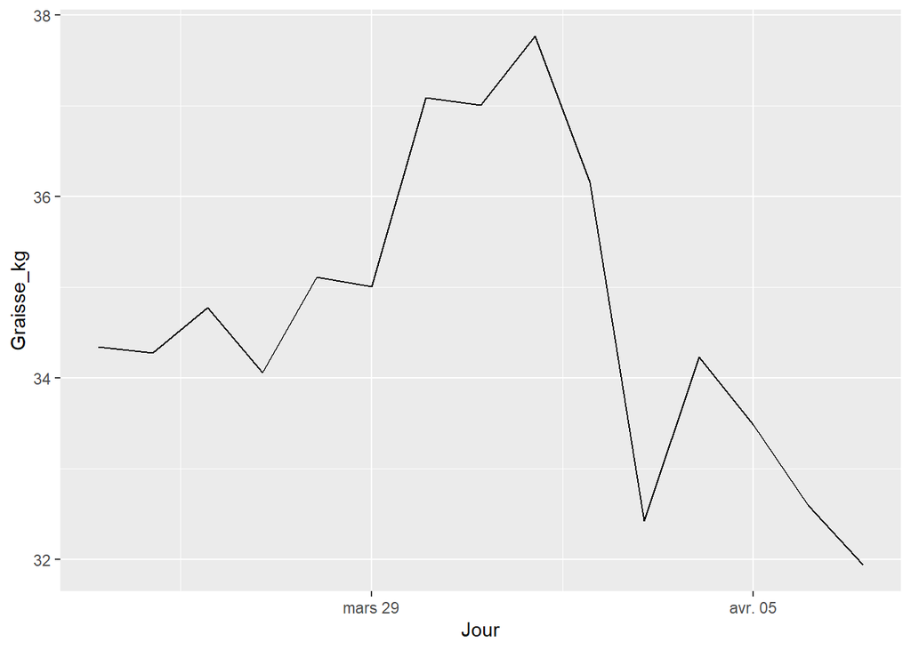

```r
library(ggplot2)
ggplot(data2,aes(x=Jour,y=Graisse_kg)) +
geom_line()
```

```r
data2$Graisse_kg[1] - data2$Graisse_kg[length(data2$Jour)]
```

```
## [1] 2.4019
```

La quantité totale de matière grasse perdue est de 2.4019 kg, passant de Y 34.3416 kg au début à 31.9397 kg à la fin du régime.

# 6. faire la prévision de matière grasse perdue si le régime avait duré 3 jours de plus

il faut faire une modélisation. vue qu’on n’observe pas de tendance, on va plutot essayer de modéliser cette serie de données en utilisant deux regressions lineaires.

## 6.1 pretraitement de la variable jour :

```r
data2$Jour_num <- as.numeric(as.Date(data2$Jour))
```

```r
mode(data2$Jour_num)
```

```
## [1] "numeric"
```

## 6.2 segmentation du jeu de données de la 2e phase

```r
# le point le plus haut (jour où il a atteint la quantité de matière grace maximum est 2021-04-01)

which(data2$Graisse_kg==max(data2$Graisse_kg))
```

```
## [1] 9
```

```r
to = which(data2$Graisse_kg==max(data2$Graisse_kg))
```

```r
to
```

```
## [1] 9
```

```r
ech1 <- data2[(1:to),]
```

```r
ech2 <- data2[-(1:to),]
```

```r
head(ech1)
```

```
##         Jour    Heure Poids Graisse_% poids_lisse      ecart poids_midi
## 1 2021-03-24 18.83333 104.7      32.8    99.38076 -0.2890040   104.4110
## 2 2021-03-25 13.18333 104.5      32.8    99.80159 -0.7098360   103.7902
## 3 2021-03-26 10.66667 103.8      33.5    99.43788 -0.3461241   103.4539
## 4 2021-03-27 19.00000 104.8      32.5    99.33470 -0.2429395   104.5571
## 5 2021-03-28 16.50000 104.8      33.5    99.96510 -0.8733437   103.9267
## 6 2021-03-29 15.00000 104.5      33.5   100.12360 -1.0318489   103.4682
##   Graisse_kg Jour_num
## 1    34.3416    18710
## 2    34.2760    18711
## 3    34.7730    18712
## 4    34.0600    18713
## 5    35.1080    18714
## 6    35.0075    18715
```

## 6.3 visualisation des deux echantillons

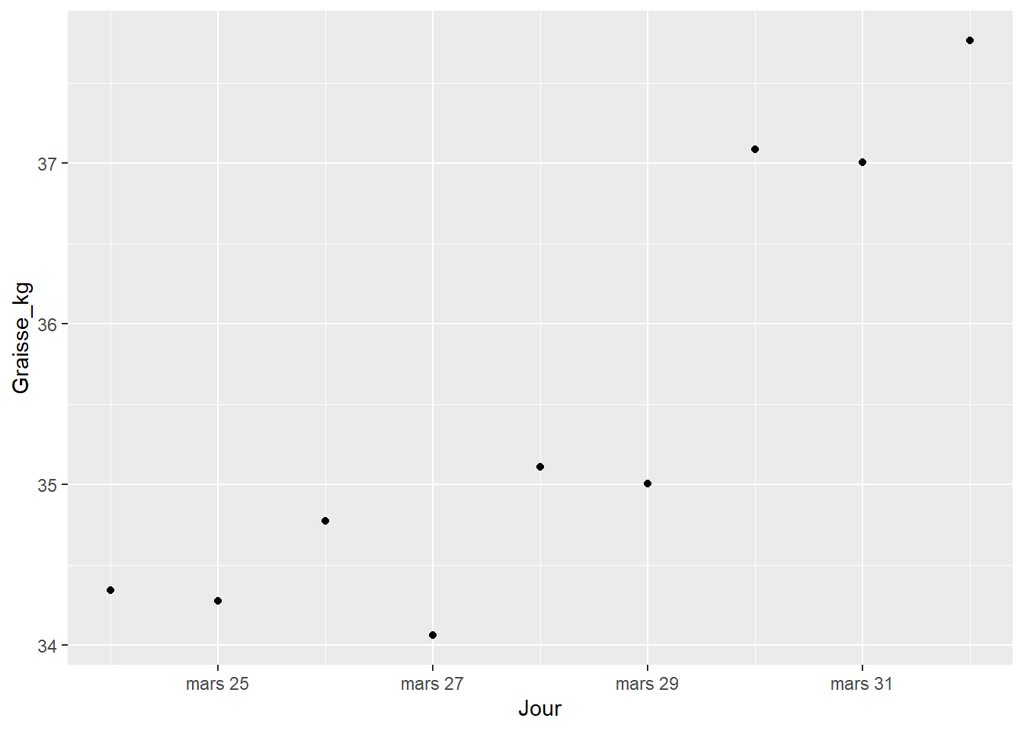

```r
library(ggplot2)
ggplot(ech1,aes(x=Jour,y=Graisse_kg)) +
geom_point()
```

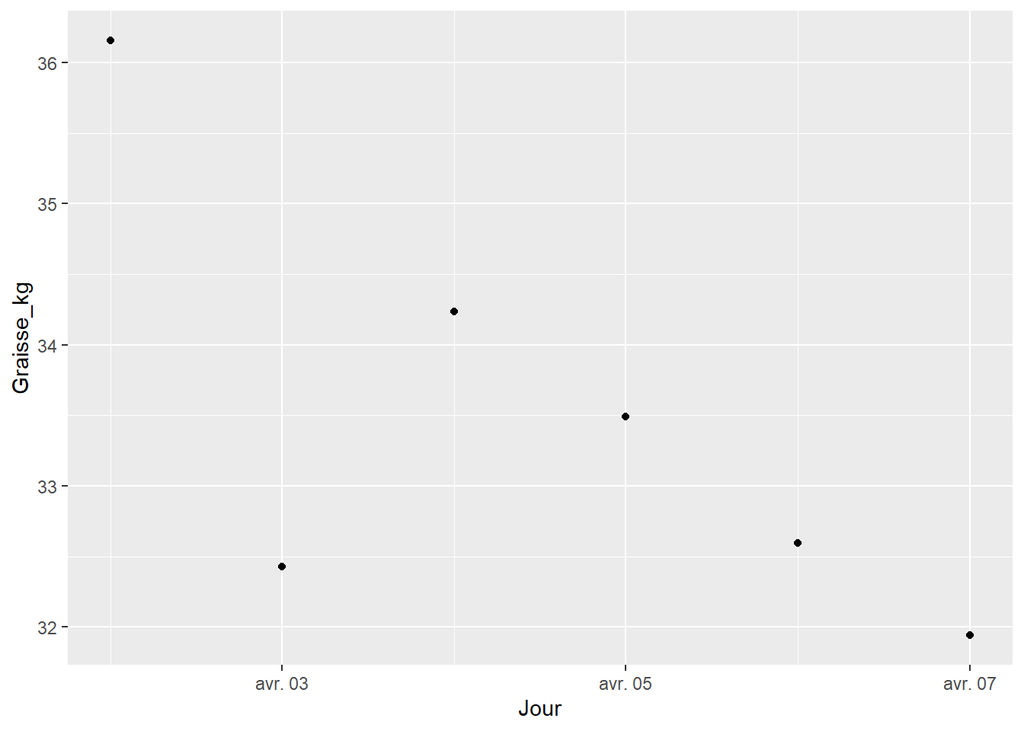

```r
library(ggplot2)
ggplot(ech2,aes(x=Jour,y=Graisse_kg)) +
geom_point()
```

On voit alors qu’on peut facilement faire des regressions lineaires sur nos deux échantillons.

## 6.4 Regression lineaire

### 6.4.1 Echantillon 1

```r
res_lm1 <- lm(Graisse_kg~Jour_num, data=ech1)
```

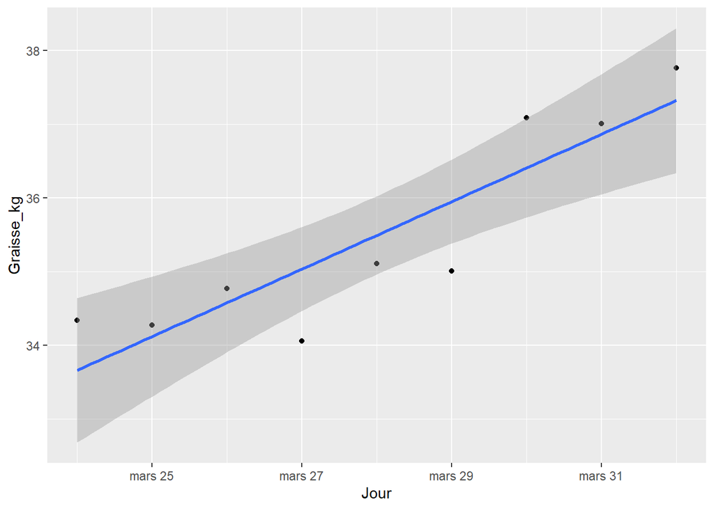

```r
library(ggplot2)
ggplot(ech1,aes(x=Jour,y=Graisse_kg)) +
geom_point()+
geom_smooth(method = "lm", se = TRUE)
```

```r
res_lm2 <- lm(Graisse_kg~Jour_num, data=ech2)
```

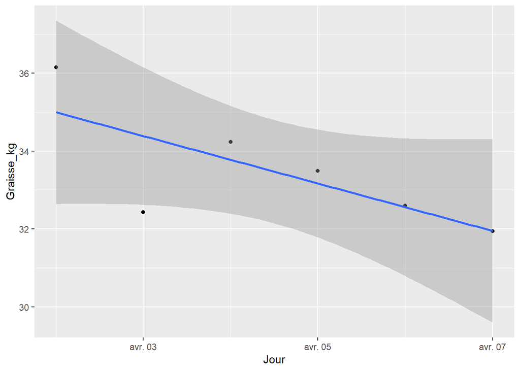

```r
library(ggplot2)
ggplot(ech2,aes(x=Jour,y=Graisse_kg)) +
geom_point()+
geom_smooth(method = "lm", se = TRUE)
```

## 6.5 Les trois prochains jours

```r
t1 <- as.numeric(as.Date("2021-04-08"))
t2 <- as.numeric(as.Date("2021-04-09"))
t3 <- as.numeric(as.Date("2021-04-10"))
```

```r
data3 <- data.frame(c(t1,t2,t3))
```

```r
colnames(data3) <- "Jour_num"
```

```r
data3
```

```
##   Jour_num
## 1    18725
## 2    18726
## 3    18727
```

```r
graisse_predict <- predict.lm(res_lm2, data3)
graisse_predict
```

```
##        1        2        3
## 31.34140 30.73239 30.12337
```

Choix du modèle : Le choix d’utiliser res_lm2 pour les prévisions est judicieux, car il représente la tendance la plus récente et est donc plus pertinent pour les prévisions à court terme.

## 6.6 visualisation de la quantité de matières grasse predictes

```r
data3$Jour <- c(as.Date("2021-04-08"), as.Date("2021-04-09"), as.Date("2021-04-10"))
data3$Graisse_kg <- graisse_predict
```

```r
data3
```

```
##   Jour_num       Jour Graisse_kg
## 1    18725 2021-04-08   31.34140
## 2    18726 2021-04-09   30.73239
## 3    18727 2021-04-10   30.12337
```

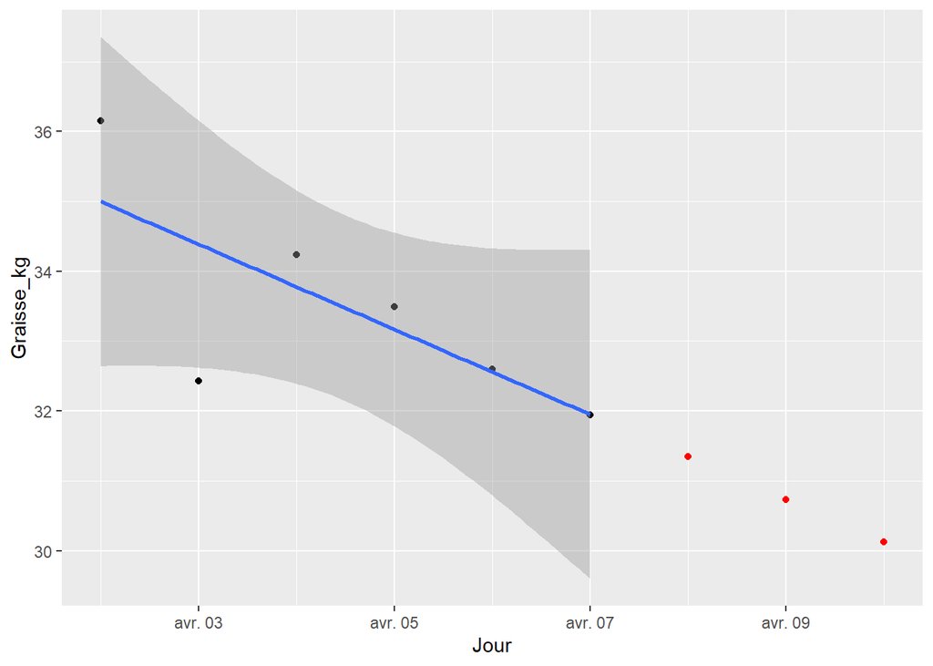

```r
library(ggplot2)
ggplot(ech2,aes(x=Jour,y=Graisse_kg)) +
geom_point()+
geom_smooth(method = "lm", se = TRUE)+
geom_point(data = data3, aes(x = Jour, y = Graisse_kg), color = "red")
```

```r
data2$Graisse_kg[1] - data3$Graisse_kg[length(data3$Graisse_kg)]
```

```
## [1] 4.218229
```

Alors si cette personne avait continué le regime, elle aurait perdu 4.218229 kg contre 2.4019 kg si elle n’avait pas continué le regime.